# Proyecto Final - Parte 4

Alsea, S.A.B. de C.V. (ALSEA.MX)

Nicole Getzabel Flores Godínez

Andrea Gutiérrez Rentería

Isaac Emiliano Meza López

María Fernanda Gómez Flores

# 1 Introducción

En la tercera entrega analizamos los rendimientos de Alsea y utilizamos el movimiento browniano geométrico para simular posibles trayectorias de su precio. Ese análisis nos permitió reconocer una limitación importante: la volatilidad no necesariamente permanece constante y los movimientos extremos pueden ser más frecuentes que los previstos por una distribución normal. En esta cuarta entrega continuamos ese trabajo mediante modelos de varianza que permiten estudiar cómo cambia el riesgo a través del tiempo y comparar qué tan bien distintas metodologías anticipan esos movimientos. Para esto utilizamos los rendimientos logarítmicos diarios de la acción y trabajamos con información comprendida entre enero de 2021 y septiembre de 2026.

El análisis incluye cuatro metodologías. Primero estimamos la volatilidad con promedios móviles y comparamos distintas ventanas para seleccionar el valor de $m$ con mejor desempeño. Después utilizamos el modelo EWMA y estimamos su parámetro de decaimiento $\lambda$. También aplicamos el modelo Data Driven EWMA, en el que obtenemos el valor óptimo de $\alpha$ directamente a partir de los datos. Finalmente, estimamos modelos ARCH/GARCH siguiendo el procedimiento trabajado en clase: primero definimos la ecuación de la media con un modelo ARMA, evaluamos la presencia de efectos ARCH y después comparamos distintas especificaciones de varianza mediante verosimilitud, AIC, BIC, persistencia y parsimonia.

Para evaluar la capacidad predictiva de los modelos reservamos las sesiones del 5 al 30 de octubre de 2026 como periodo fuera de muestra. Los parámetros se estiman únicamente con información disponible hasta el 30 de septiembre, de manera que los datos utilizados para evaluar los pronósticos no intervienen en su selección. Finalmente, comparamos las estimaciones diarias con la volatilidad realizada y analizamos qué modelo captura mejor los periodos de mayor riesgo, cuál reacciona más rápido ante cambios en el mercado, cuál produce estimaciones más estables y cuáles tienden a sobreestimar o subestimar la volatilidad.

# 2 Estimación de modelos

## 2.1 Datos y rendimientos

Descargamos los precios ajustados de Alsea y calculamos los rendimientos logarítmicos diarios, de la misma forma que en la entrega anterior:

$$r_t=\ln\left(\frac{P_t}{P_{t-1}}\right)$$

Para evitar utilizar información futura en la estimación, separamos los datos en dos periodos. El periodo de estimación termina el 30 de septiembre de 2026 y el periodo de evaluación comprende las sesiones entre el 5 y el 30 de octubre de 2026.

Periodos utilizados para estimación y evaluación

| Periodo | Inicio | Fin | Observaciones |
| --- | --- | --- | --- |
| Estimación | 2021-01-04 | 2026-09-30 | 1445 |
| Evaluación fuera de muestra | 2026-10-05 | 2026-10-30 | 20 |

Siguiendo la estructura trabajada en clase, dentro del periodo de estimación hacemos una división 70/30. El primer 70% se utiliza como muestra de entrenamiento y el 30% restante como muestra de prueba para comparar el desempeño de las especificaciones. Una vez elegida la estructura de cada modelo, utilizamos toda la información disponible hasta el 30 de septiembre para obtener la estimación final que se evalúa en octubre. De esta manera, octubre no participa en la selección de los modelos ni de sus parámetros.

División interna del periodo de estimación

| Muestra | Observaciones | Inicio | Fin |
| --- | --- | --- | --- |
| Primer 70% | 1011 | 2021-01-04 | 2025-01-07 |
| Último 30% | 434 | 2025-01-08 | 2026-09-30 |

## 2.2 Promedios móviles

El promedio móvil estima la varianza utilizando los últimos $m$ rendimientos al cuadrado:

$$\hat\sigma_t^2(m)=\frac{1}{m}\sum_{i=1}^{m}r_{t-i}^2$$

La elección de $m$ es importante porque una ventana pequeña reacciona rápidamente a los movimientos recientes, pero también puede ser más ruidosa. Una ventana más grande produce una estimación más estable, pero puede tardar más en reconocer cambios en el nivel de volatilidad.

Probamos las ventanas de 5, 10, 20 y 40 sesiones. Para elegir el valor de $m$ comparamos los pronósticos de cada ventana en el último 30% del periodo de estimación utilizando RMSE, MAE y QLIKE sobre la varianza.

Comparación de ventanas para el promedio móvil

| m | RMSE | MAE | QLIKE | Rango_RMSE | Rango_MAE | Rango_QLIKE | Rango_promedio |
| --- | --- | --- | --- | --- | --- | --- | --- |
| 5 | 0.001207 | 0.000448 | 105.3272 | 4 | 4 | 2 | 3.333333 |
| 10 | 0.001163 | 0.000436 | 104.9400 | 3 | 3 | 1 | 2.333333 |
| 20 | 0.001141 | 0.000435 | 111.4071 | 2 | 2 | 3 | 2.333333 |
| 40 | 0.001129 | 0.000432 | 123.6997 | 1 | 1 | 4 | 2.000000 |

Seleccionamos **M40** porque presenta el mejor rango promedio entre las tres medidas de error. Asignamos igual importancia a RMSE, MAE y QLIKE para equilibrar errores grandes, errores absolutos y ajuste relativo de varianza. Este criterio de rangos es una regla de decisión para Alsea, no una regla universal: la ventana seleccionada depende de la pérdida que se priorice para administrar riesgo. De esta manera, la elección no depende de una sola observación ni únicamente de qué curva se ve más suave, sino de su capacidad para anticipar la varianza en datos que no participaron en el cálculo de cada pronóstico.

Para observar cómo cambia la estimación conforme aumenta la ventana, comparamos las cuatro trayectorias durante el periodo de estimación.

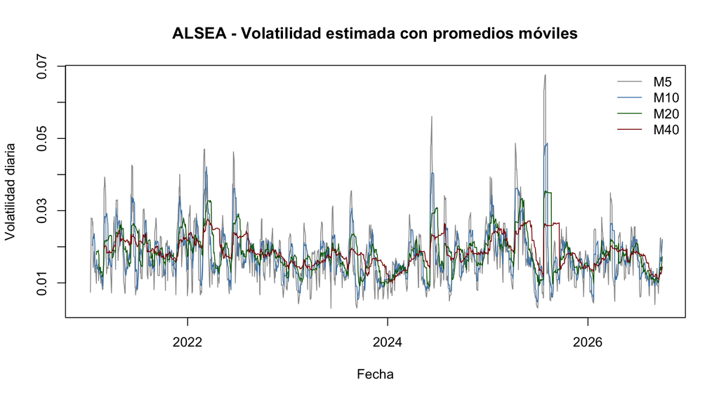

En la gráfica se observa el intercambio entre sensibilidad y estabilidad. Las ventanas cortas presentan cambios más fuertes cuando aparece un rendimiento extremo, mientras que las ventanas largas suavizan esos movimientos. Sin embargo, esa estabilidad también implica que un choque permanece durante más tiempo dentro de la ventana y que el modelo puede reaccionar con retraso cuando el nivel de riesgo cambia.

## 2.3 Modelo EWMA

El modelo EWMA asigna mayor peso a la información reciente y reduce de forma gradual la importancia de los rendimientos anteriores. La recursión utilizada en clase es:

$$\hat\sigma_1^2=r_1^2$$

$$\hat\sigma_t^2=(1-\lambda)r_{t-1}^2+\lambda\hat\sigma_{t-1}^2$$

Cuando $\lambda$ es alto, el modelo tiene mayor memoria y la volatilidad cambia más lentamente. Cuando es menor, los rendimientos recientes tienen más peso y la estimación responde más rápido.

Para seleccionar $\lambda$ utilizamos la verosimilitud normal sin constantes, siguiendo el procedimiento visto en clase:

$$\ell(\lambda)=\sum_t\left[-\ln(\hat\sigma_t^2)-\frac{r_t^2}{\hat\sigma_t^2}\right]$$

Selección del parámetro lambda en EWMA

| Especificacion | Lambda | Vida_media |
| --- | --- | --- |
| Estimado con primer 70% | 0.8699 | 4.9742 |
| Estimado con toda la muestra hasta septiembre | 0.9302 | 9.5800 |
| RiskMetrics | 0.9400 | 11.2023 |

El valor final estimado es $\hat\lambda=$ 0.9302. Lo seleccionamos porque maximiza la verosimilitud normal con los datos de Alsea hasta septiembre, en lugar de utilizar automáticamente 0.94. El resultado del primer 70% permite observar la sensibilidad del parámetro a la muestra; el valor final se reestima con toda la información hasta septiembre. Octubre no participa en la optimización ni en la selección de lambda. Su vida media es de aproximadamente 9.6 sesiones, lo que indica cuánto tarda en reducirse a la mitad el peso de un choque en la estimación de volatilidad.

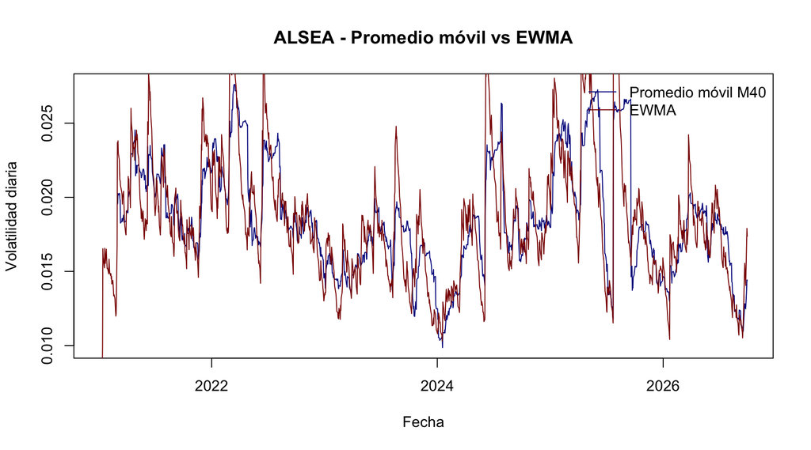

A diferencia del promedio móvil, EWMA no elimina una observación de forma repentina cuando sale de una ventana fija. Su peso disminuye gradualmente. Por esta razón, puede producir una trayectoria más continua y evitar algunos cambios artificiales que aparecen en los promedios móviles. Además, el parámetro estimado permite que la respuesta ante nueva información dependa del peso $1-\lambda$, mientras que en el promedio móvil la reacción depende directamente del tamaño de la ventana elegida. Esta diferencia se contrasta nuevamente en el periodo fuera de muestra, donde medimos cuánto cambia cada estimación después del mayor choque de octubre. Por ello, no consideramos que una trayectoria más suave sea necesariamente mejor: si el riesgo aumenta repentinamente, reaccionar con retraso puede llevar a subestimar la exposición de la acción.

## 2.4 Data Driven EWMA

El Data Driven EWMA trabaja directamente sobre la volatilidad y utiliza los valores absolutos de los rendimientos centrados. Primero calculamos:

$$\rho=\operatorname{corr}\left(r_t-\bar
r,\operatorname{sign}(r_t-\bar r)\right)$$

$$z_t=\frac{|r_t-\bar
r|}{\rho}$$

Después estimamos la volatilidad mediante:

$$\hat\sigma_1=z_1$$

$$\hat\sigma_t=\alpha
z_{t-1}+(1-\alpha)\hat\sigma_{t-1}$$

En este modelo $\alpha$ representa el peso asignado a la información más reciente. El valor óptimo se obtiene minimizando la suma de errores cuadrados entre $z_t$ y la volatilidad estimada.

Selección del parámetro alpha en Data Driven EWMA

| Muestra | Media | Rho | Alpha | Vida_media |
| --- | --- | --- | --- | --- |
| Primer 70% | 6e-04 | 0.7519 | 0.0391 | 17.3863 |
| Toda la muestra hasta septiembre | 4e-04 | 0.7418 | 0.0354 | 19.2071 |

El valor final de $\alpha$ es $\hat\alpha=$ 0.0354. Lo obtenemos minimizando los errores cuadrados entre la señal transformada $z_t$ y el pronóstico obtenido con información rezagada. El valor del primer 70% documenta el entrenamiento; para el pronóstico final lo reestimamos con la información hasta septiembre, sin utilizar octubre. A diferencia de $\lambda$ en EWMA, un alpha más grande significa mayor peso sobre la observación reciente. Por eso, para comparar directamente ambos modelos es útil observar $\alpha$ frente a $1-\lambda$. En Alsea, el peso de la observación más reciente es 0.0354 en DDEWMA y 0.0698 en EWMA.

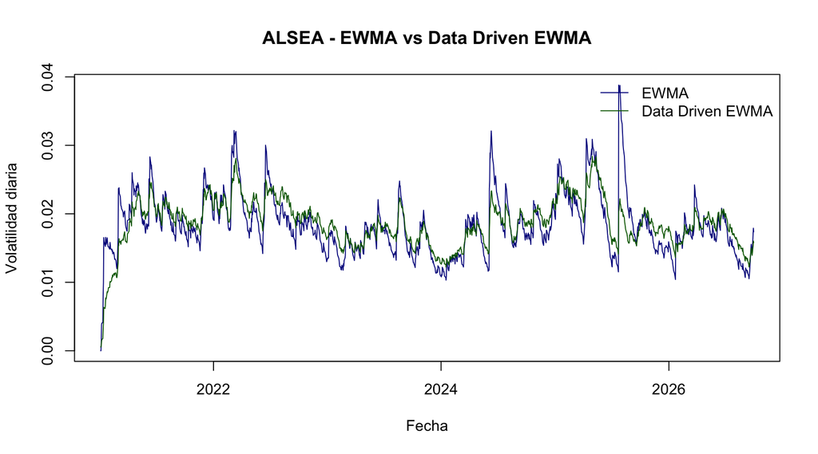

El DDEWMA tiene una diferencia importante frente al EWMA tradicional: los movimientos extremos entran mediante su valor absoluto y no mediante el rendimiento al cuadrado. Por esta razón, puede reaccionar de manera diferente ante días con movimientos muy grandes. La comparación fuera de muestra nos permitirá evaluar si esa diferencia mejora la estimación de riesgo para Alsea. Es importante distinguir entre suavizar los movimientos diarios y anticipar episodios de estrés: una menor variabilidad del pronóstico no significa automáticamente menor error.

## 2.5 Modelo ARCH/GARCH

Para ARCH/GARCH seguimos el procedimiento utilizado en clase. Primero modelamos la ecuación de la media mediante un ARMA. Después analizamos las innovaciones de esa ecuación y evaluamos si existe evidencia de efectos ARCH. Finalmente estimamos seis modelos de la familia ARCH/GARCH y seleccionamos el que tenga un mejor equilibrio entre ajuste y parsimonia.

### 2.5.1 Modelo ARMA para la media

La ecuación general de la media es:

$$r_t=\mu_t+\epsilon_t$$

Para determinar cómo se comporta $\mu_t$ utilizamos `auto.arima` con $d=0$, imponiendo estacionariedad y sin componente estacional, de la misma manera que en el notebook de clase.

Modelo seleccionado para la ecuación de la media

| Modelo | AIC | BIC |
| --- | --- | --- |
| ARMA(0,1) | -5162.601 | -5152.764 |

El modelo seleccionado para la ecuación de la media es **ARMA(0,1)**. La selección se realiza con `auto.arima`, de la misma forma que en el notebook de clase, comparando distintas especificaciones estacionarias para elegir una estructura parsimoniosa de la media. En la tabla reportamos además el AIC y BIC del modelo seleccionado como medidas de referencia de su ajuste. La restricción $d=0$ y `stationary = TRUE` se aplican porque modelamos rendimientos, no niveles de precios. El orden se obtiene mediante el procedimiento automático y su criterio de información, no por inspección visual. Al modelar primero la media evitamos atribuir a la varianza patrones que en realidad provengan de dependencia serial en los rendimientos. Una vez filtrada esa dinámica, analizamos las innovaciones $\epsilon_t$ para determinar si todavía existe heterocedasticidad condicional que justifique un modelo ARCH/GARCH.

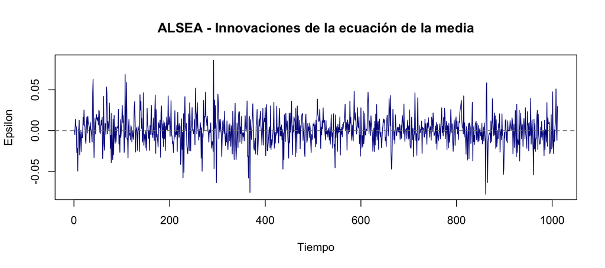

### 2.5.2 Prueba ARCH-LM

Con las innovaciones de la ecuación de la media evaluamos si existe estructura ARCH remanente. La hipótesis nula indica que los cuadrados de las innovaciones no presentan dependencia con sus rezagos:

$$H_0:\text{ no existen efectos
ARCH}$$

$$H_1:\text{ existe estructura
ARCH}$$

Si el p-valor es menor a 0.05 rechazamos $H_0$ y consideramos que existe evidencia de heterocedasticidad condicional.

Prueba ARCH-LM sobre las innovaciones de la media

| Estadistico | Grados_libertad | p_valor | Conclusion |
| --- | --- | --- | --- |
| 46.2424 | 20 | 7e-04 | Existe evidencia de estructura ARCH |

El p-valor obtenido es 0.0007465. Por lo tanto, rechazamos la hipótesis nula y encontramos evidencia de que la varianza de las innovaciones cambia con el tiempo y depende de observaciones anteriores.

### 2.5.3 Estimación de modelos candidatos

Estimamos los mismos seis modelos de la familia que se trabajaron en el notebook de clase:

Modelos ARCH/GARCH candidatos

| modelo | p | q |
| --- | --- | --- |
| ARCH(1) | 1 | 0 |
| ARCH(2) | 2 | 0 |
| GARCH(1,1) | 1 | 1 |
| GARCH(1,2) | 1 | 2 |
| GARCH(2,1) | 2 | 1 |
| GARCH(2,2) | 2 | 2 |

Para comparar los modelos utilizamos verosimilitud, AIC, BIC y persistencia. Los criterios AIC y BIC penalizan la complejidad, por lo que ayudan a evitar seleccionar un modelo con más parámetros solamente porque obtiene un ajuste ligeramente mejor.

$$AIC=-2\ell+2k$$

$$BIC=-2\ell+\ln(n)k$$

La persistencia se obtiene como la suma de los coeficientes ARCH y GARCH. Cuando esta suma es cercana a uno, los choques sobre la volatilidad tardan más en desaparecer.

Comparación de modelos ARCH/GARCH

| Modelo | Convergencia | logLik | AIC | BIC | alpha_sum | beta_sum | Persistencia | p_max_varianza |
| --- | --- | --- | --- | --- | --- | --- | --- | --- |
| ARCH(1) | TRUE | 944.8437 | -1881.687 | -1862.013 | 0.9990 | 0.0000 | 0.9990 | 0.0000 |
| ARCH(2) | TRUE | 2596.6860 | -5183.372 | -5158.779 | 0.1936 | 0.0000 | 0.1936 | 0.0136 |
| GARCH(1,1) | TRUE | 2588.8687 | -5167.737 | -5143.144 | 0.0133 | 0.9760 | 0.9893 | 0.0000 |
| GARCH(1,2) | TRUE | 2589.4172 | -5166.834 | -5137.322 | 0.0225 | 0.9588 | 0.9813 | 0.0000 |
| GARCH(2,1) | TRUE | 2588.8898 | -5165.780 | -5136.267 | 0.0129 | 0.9770 | 0.9899 | 1.0000 |
| GARCH(2,2) | TRUE | 2589.4172 | -5164.834 | -5130.404 | 0.0225 | 0.9588 | 0.9813 | 1.0000 |

Para seleccionar el modelo primero revisamos que la estimación converja, que la persistencia sea menor a uno y que los coeficientes ARCH/GARCH sean estadísticamente significativos al 5%. Entre los modelos que cumplen estas condiciones elegimos el menor BIC, porque combina el ajuste del modelo con una penalización más fuerte por agregar parámetros y por lo tanto favorece la parsimonia. Si ninguna especificación cumple todas las condiciones de significancia, conservamos como referencia los modelos convergentes y estacionarios y seleccionamos el de menor BIC, señalando esta limitación en la interpretación.

El modelo seleccionado es **ARCH(2)**. Priorizamos convergencia, persistencia inferior a uno y significancia de los parámetros de varianza; entre candidatos admisibles, minimizamos BIC para favorecer la parsimonia. Si ningún modelo satisface todos los filtros, se aplica la regla alternativa descrita sin atribuirle propiedades que no verificó. Su persistencia es de 0.1936 y el mayor p-valor entre sus coeficientes ARCH/GARCH es 0.0136. La persistencia nos permite interpretar qué tan rápido desaparece el efecto de un choque. Una persistencia más cercana a uno implica que la volatilidad tarda más en regresar a su nivel de largo plazo. Financiera y operativamente, esta memoria del riesgo importa porque un aumento temporal de incertidumbre puede afectar durante varias sesiones las estimaciones utilizadas para decidir posiciones y límites de exposición.

### 2.5.4 Reestimación del modelo elegido hasta septiembre de 2026

Una vez seleccionados los órdenes del modelo, mantenemos esa estructura y volvemos a estimar sus parámetros utilizando toda la información hasta el 30 de septiembre de 2026. Esto permite aprovechar toda la información disponible antes de comenzar el periodo fuera de muestra.

Parámetros finales del modelo ARCH(2)

| Parametro | Estimacion |
| --- | --- |
| mu | 0.000394 |
| ma1 | 0.031562 |
| omega | 0.000304 |
| alpha1 | 0.088953 |
| alpha2 | 0.066334 |

# 3 Evaluación de modelos

Para evaluar la capacidad predictiva utilizamos las sesiones del 5 al 30 de octubre de 2026. Ninguno de los parámetros se vuelve a estimar con información de octubre. Sin embargo, después de observar el rendimiento de una sesión, este sí puede utilizarse para actualizar el pronóstico de la sesión siguiente, que es precisamente la forma en que se utilizarían estos modelos diariamente.

Como medida de referencia utilizamos la volatilidad realizada indicada en la consigna:

$$\sigma_{t,realizada}=\sqrt{r_t^2}=|r_t|$$

Esta medida es muy variable porque utiliza una sola observación por día, pero permite comparar todos los modelos con el mismo valor observado. No es la volatilidad condicional verdadera, que no puede observarse directamente: RMSE y MAE miden la distancia frente a este proxy. Los pronósticos son de un paso; el rendimiento de la sesión $t$ puede actualizar el pronóstico de $t+1$, pero no el de su propia sesión.

## 3.1 Pronósticos diarios de octubre

Volatilidad observada y estimada del 5 al 30 de octubre de 2026

| Fecha | Rendimiento | Volatilidad_realizada | MA | EWMA | DDEWMA | ARCH(2) |
| --- | --- | --- | --- | --- | --- | --- |
| 2026-10-05 | 0.00547 | 0.00547 | 0.01444 | 0.01664 | 0.01554 | 0.01751 |
| 2026-10-06 | 0.00890 | 0.00890 | 0.01447 | 0.01611 | 0.01524 | 0.01755 |
| 2026-10-07 | 0.01352 | 0.01352 | 0.01453 | 0.01572 | 0.01510 | 0.01767 |
| 2026-10-08 | 0.01566 | 0.01566 | 0.01465 | 0.01558 | 0.01519 | 0.01800 |
| 2026-10-09 | 0.01748 | 0.01748 | 0.01484 | 0.01558 | 0.01538 | 0.01831 |
| 2026-10-12 | 0.00288 | 0.00288 | 0.01449 | 0.01572 | 0.01565 | 0.01854 |
| 2026-10-13 | 0.01915 | 0.01915 | 0.01446 | 0.01518 | 0.01522 | 0.01798 |
| 2026-10-14 | 0.00463 | 0.00463 | 0.01469 | 0.01549 | 0.01557 | 0.01833 |
| 2026-10-15 | 0.01317 | 0.01317 | 0.01460 | 0.01499 | 0.01522 | 0.01813 |
| 2026-10-16 | 0.01398 | 0.01398 | 0.01474 | 0.01487 | 0.01529 | 0.01788 |
| 2026-10-19 | 0.02204 | 0.02204 | 0.01478 | 0.01481 | 0.01540 | 0.01818 |
| 2026-10-20 | 0.00057 | 0.00057 | 0.01507 | 0.01543 | 0.01589 | 0.01887 |
| 2026-10-21 | -0.04555 | 0.04555 | 0.01507 | 0.01488 | 0.01533 | 0.01829 |
| 2026-10-22 | 0.03053 | 0.03053 | 0.01636 | 0.01873 | 0.01698 | 0.02218 |
| 2026-10-23 | 0.00869 | 0.00869 | 0.01706 | 0.01978 | 0.01782 | 0.02309 |
| 2026-10-26 | 0.00231 | 0.00231 | 0.01711 | 0.01922 | 0.01758 | 0.01938 |
| 2026-10-27 | -0.00732 | 0.00732 | 0.01710 | 0.01854 | 0.01705 | 0.01756 |
| 2026-10-28 | 0.00270 | 0.00270 | 0.01710 | 0.01799 | 0.01682 | 0.01761 |
| 2026-10-29 | 0.01928 | 0.01928 | 0.01711 | 0.01736 | 0.01633 | 0.01758 |
| 2026-10-30 | -0.00664 | 0.00664 | 0.01733 | 0.01750 | 0.01665 | 0.01834 |

La tabla anterior permite contrastar, para cada sesión, el movimiento real observado con la volatilidad que cada modelo había estimado antes de conocer ese rendimiento.

## 3.2 Comparación de errores

Para complementar la tabla diaria calculamos RMSE y MAE sobre la volatilidad. También calculamos el sesgo promedio, definido como la volatilidad estimada menos la realizada. Un sesgo positivo indica que el modelo tiende a sobreestimar la volatilidad, mientras que uno negativo indica subestimación.

Evaluación fuera de muestra de los modelos de volatilidad

| Modelo | RMSE | MAE | Sesgo | Estabilidad |
| --- | --- | --- | --- | --- |
| MA | 0.01115 | 0.00872 | 0.00248 | 2e-04 |
| EWMA | 0.01169 | 0.00924 | 0.00348 | 6e-04 |
| DDEWMA | 0.01129 | 0.00892 | 0.00294 | 4e-04 |
| ARCH(2) | 0.01193 | 0.00976 | 0.00553 | 8e-04 |

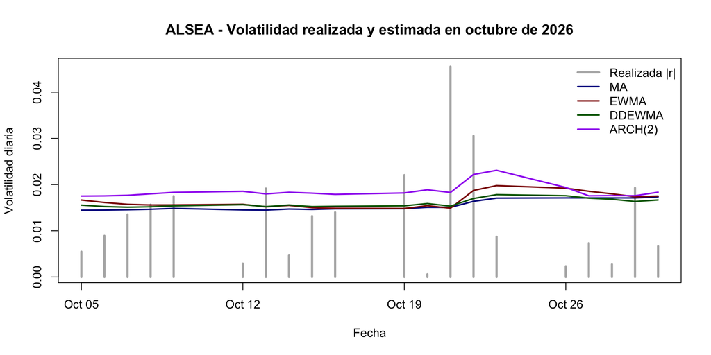

De acuerdo con el RMSE, el modelo con menor error fuera de muestra es **MA**, con un RMSE de **0.01115** en unidades de volatilidad diaria. Por MAE, el mejor resultado corresponde a **MA**, con un MAE de **0.00872**. Estas medidas no necesariamente eligen al mismo modelo porque el RMSE penaliza más los errores grandes, mientras que el MAE trata de forma más uniforme las diferencias de cada día.

# 4 Análisis e interpretación

## 4.1 ¿Qué modelo captura mejor los periodos de alta volatilidad?

Para responder esta pregunta identificamos como días de alta volatilidad las observaciones de octubre que se encuentran en el 25% superior de la volatilidad realizada. Después comparamos el error absoluto promedio de cada modelo únicamente en esos días.

Error durante los días de mayor volatilidad

| Modelo | MAE_alta |
| --- | --- |
| MA | 0.01175 |
| EWMA | 0.01112 |
| DDEWMA | 0.01146 |
| ARCH(2) | 0.00847 |

El modelo que se acerca más a la volatilidad realizada durante los días más extremos es **ARCH(2)**, con un error absoluto promedio de **0.00847**. Este resultado se obtiene considerando únicamente las sesiones que superan el percentil 75 de $|r_t|$ y no necesariamente coincide con el mejor modelo del mes completo. Esto es relevante desde una perspectiva financiera porque los errores durante periodos tranquilos y los errores durante periodos de estrés no tienen el mismo costo. Un modelo que subestima el riesgo precisamente cuando ocurren movimientos grandes puede producir límites de exposición o medidas de riesgo demasiado optimistas. Esta identificación de días extremos es *ex post*, porque se basa en $|r_t|$ observado: permite evaluar episodios de estrés, no predecir de antemano qué días serán extremos.

## 4.2 ¿Qué modelo reacciona más rápidamente ante cambios en el mercado?

Para medir la reacción tomamos el día con el rendimiento absoluto más grande de octubre. Como el pronóstico de ese mismo día se realiza antes de observar el choque, analizamos cuánto aumenta la volatilidad estimada para la siguiente sesión.

Reacción de cada modelo después del mayor choque de octubre

| Modelo | Antes | Despues | Cambio_relativo |
| --- | --- | --- | --- |
| MA | 0.01507 | 0.01636 | 0.08603 |
| EWMA | 0.01488 | 0.01873 | 0.25871 |
| DDEWMA | 0.01533 | 0.01698 | 0.10779 |
| ARCH(2) | 0.01829 | 0.02218 | 0.21311 |

El modelo que presenta el mayor ajuste inmediato después del choque es EWMA. Una reacción rápida incorpora un choque ya observado al pronóstico de la siguiente sesión, pero puede generar estimaciones más variables si fue transitorio. Un cambio relativo mayor no garantiza menor error predictivo.

En particular, la comparación permite distinguir la respuesta del EWMA frente al promedio móvil seleccionado: después del mayor choque, el cambio relativo de EWMA es de **25.87%**, mientras que el del promedio móvil es de **8.6%**. Así, la diferencia de reacción entre ambos modelos no se interpreta solo por su construcción teórica, sino también por el comportamiento observado fuera de muestra.

## 4.3 ¿Qué modelo presenta mayor estabilidad en sus estimaciones?

Utilizamos el cambio absoluto promedio de la volatilidad estimada entre una sesión y la siguiente. Una cifra menor significa que la trayectoria del modelo cambia de manera más gradual.

El modelo más estable durante octubre es **MA**, con un cambio absoluto promedio entre sesiones de **0.00020**. Esta estabilidad puede ser útil para la toma de decisiones porque evita que las medidas de riesgo cambien demasiado por una sola observación. Sin embargo, demasiada estabilidad también puede convertirse en rezago si el mercado entra en un nuevo régimen de volatilidad.

## 4.4 ¿Qué modelo sobreestima o subestima la volatilidad?

Sesgo promedio de las estimaciones de volatilidad

| Modelo | Sesgo | Comportamiento |
| --- | --- | --- |
| MA | 0.00248 | Sobreestima en promedio |
| EWMA | 0.00348 | Sobreestima en promedio |
| DDEWMA | 0.00294 | Sobreestima en promedio |
| ARCH(2) | 0.00553 | Sobreestima en promedio |

La tabla muestra que el sesgo no es igual entre los modelos. Una sobreestimación frente al proxy $|r_t|$ puede indicar una postura más conservadora, pero no demuestra por sí sola exceso de capital, porque volatilidad condicional y rendimiento absoluto de una sesión no son magnitudes idénticas. Una subestimación puede parecer más eficiente durante periodos tranquilos, pero representa un riesgo mayor si el modelo deja de reconocer movimientos importantes del mercado.

# 5 Conclusión

En la entrega anterior observamos que el GBM es útil para representar precios futuros, pero mantener una volatilidad constante limita su capacidad para describir cambios de riesgo. En esta cuarta entrega comparamos modelos de volatilidad de Alsea utilizando información de 2021 a septiembre de 2026 y dejando las sesiones evaluadas de octubre como un periodo fuera de muestra. Así, pasamos de reconocer las limitaciones del supuesto de volatilidad constante a estimar cómo cambia el riesgo diario. Los resultados muestran que la elección del modelo modifica tanto la velocidad con la que se reconoce un cambio en el riesgo como la estabilidad de las estimaciones.

Los promedios móviles permiten observar con claridad el efecto de la ventana. Una ventana corta reacciona con mayor intensidad a las observaciones recientes, mientras que una ventana larga produce una trayectoria más estable, aunque puede responder con retraso. El EWMA mejora esta dinámica al reducir gradualmente el peso de las observaciones anteriores, mientras que el Data Driven EWMA utiliza una medida basada en el valor absoluto de los rendimientos y obtiene su parámetro de suavizamiento directamente de los datos.

En el caso de ARCH/GARCH, primero modelamos la media con un ARMA(0,1) y después analizamos las innovaciones. De los seis modelos de varianza considerados, seleccionamos **ARCH(2)** con base en BIC, verosimilitud, convergencia, persistencia y parsimonia. Esta familia tiene la ventaja de modelar explícitamente la dependencia temporal de la varianza y permite que un choque modifique de forma diferente la volatilidad futura según los parámetros estimados.

Durante el periodo fuera de muestra, el menor RMSE corresponde a **MA** y el menor MAE a **MA**. En los días de mayor volatilidad, el modelo que mejor se aproxima al riesgo realizado es **ARCH(2)**, mientras que el modelo con mayor estabilidad es **MA**. Esto muestra que no necesariamente existe un modelo que sea superior en todas las características: un modelo puede ser más estable, pero reaccionar más lento, mientras que otro puede responder mejor a los choques a costa de producir estimaciones más variables.

Desde una perspectiva financiera, utilizando conjuntamente RMSE y MAE, el modelo que utilizaríamos como referencia principal para Alsea es **MA**. Esta decisión se basa en su desempeño con datos que no participaron en la estimación y no únicamente en el ajuste dentro de muestra. Aun así, consideramos importante observar también el comportamiento de los otros modelos, especialmente en periodos de alta volatilidad, porque el costo de subestimar el riesgo durante un episodio de estrés puede ser mayor que el costo de una estimación conservadora en un periodo estable.